# On Trees 🌳

# Libraries:

```r
library(tree) # To construct classification and regression trees
library(ISLR2)
library(tidyverse)
library(caret)
library(rpart.plot)
library(randomForest)
library(gbm)
```

# Regression Trees:

Using the Boston data set: A data set containing housing values in 506 suburbs of Boston. Our goal here is to ultimately predict house value (medv) based on the other features: crime, zones, industry,near river, nitrogen oxides concentration, number of rooms, proportion of old homes, distance from Boston centers, accessability to highway, tax rate, pupil-teacher ratio, and percent lower status of population.

```r
set.seed(1234)
data<-Boston
head(data)
```

|  | crim | zn | indus | chas | nox | rm | age | dis | rad | tax | ptratio | lstat | medv |
| --- | --- | --- | --- | --- | --- | --- | --- | --- | --- | --- | --- | --- | --- |
| 1 | 0.00632 | 18 | 2.31 | 0 | 0.538 | 6.575 | 65.2 | 4.0900 | 1 | 296 | 15.3 | 4.98 | 24.0 |
| 2 | 0.02731 | 0 | 7.07 | 0 | 0.469 | 6.421 | 78.9 | 4.9671 | 2 | 242 | 17.8 | 9.14 | 21.6 |
| 3 | 0.02729 | 0 | 7.07 | 0 | 0.469 | 7.185 | 61.1 | 4.9671 | 2 | 242 | 17.8 | 4.03 | 34.7 |
| 4 | 0.03237 | 0 | 2.18 | 0 | 0.458 | 6.998 | 45.8 | 6.0622 | 3 | 222 | 18.7 | 2.94 | 33.4 |
| 5 | 0.06905 | 0 | 2.18 | 0 | 0.458 | 7.147 | 54.2 | 6.0622 | 3 | 222 | 18.7 | 5.33 | 36.2 |
| 6 | 0.02985 | 0 | 2.18 | 0 | 0.458 | 6.430 | 58.7 | 6.0622 | 3 | 222 | 18.7 | 5.21 | 28.7 |

Split the data into training and test data

```r
intrain<-createDataPartition(y=data$medv, p=0.7, list=FALSE)
train_data <-data[intrain, ]
test_data <-data[-intrain, ]
```

Create a regression tree using the training data Note: remember the function is: function(dependent ~ independents, data) if you add ‘.’ next to ‘~’ then you are suggesting that all other variables are used.

```r
reg_tree<-tree(medv ~ ., train_data)
summary(reg_tree)
```

```
Regression tree:
tree(formula = medv ~ ., data = train_data)
Variables actually used in tree construction:
[1] "lstat" "rm"    "dis"   "nox"
Number of terminal nodes:  7
Residual mean deviance:  12.26 = 4277 / 349
Distribution of residuals:
   Min. 1st Qu.  Median    Mean 3rd Qu.    Max.
-10.210  -2.106  -0.010   0.000   2.130  12.120
```

The above output indicates that only 4 variables have been used in constructing the tree: lstat, rm, dis, nox. We can see that there are 7 terminal nodes. Residual mean deviance is 12.26 where residual mean deviance is the average deviance of the residuals (the differences between observed and predicted values) across all observations in the dataset. Smaller values indicate a better fit.

Now, we plot:

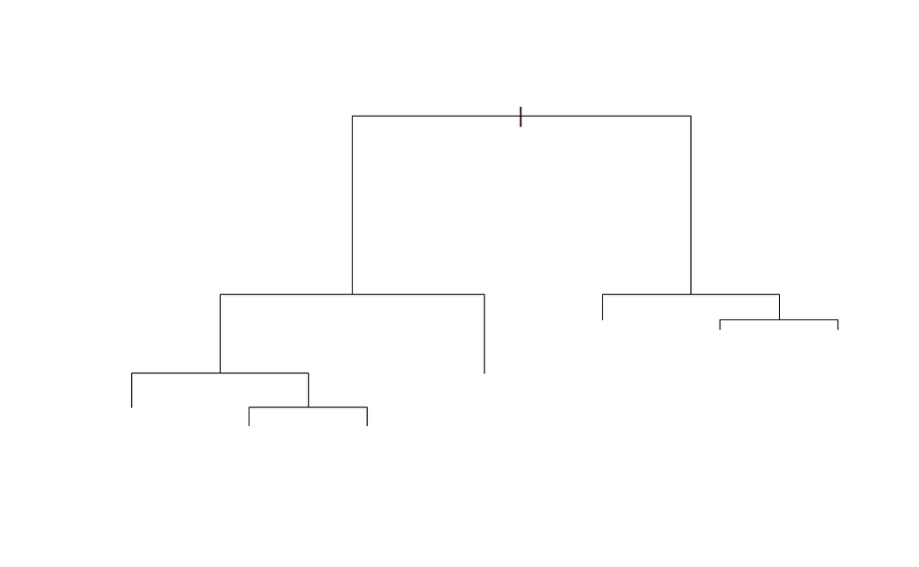

Note: The argument pretty = 0 instructs R to include the category names for any qualitative predictors (I played around with it some though and nothing really happens so maybe do some research there - I’ve included it because it seems standard)

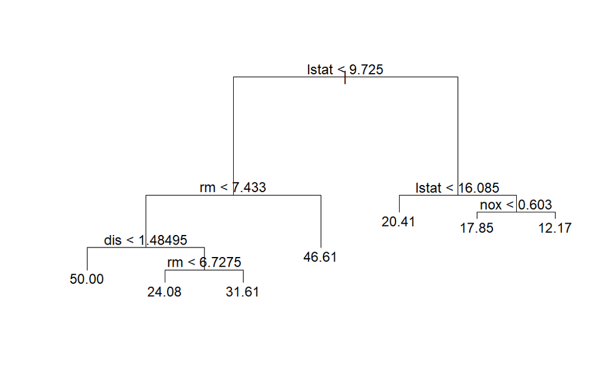

```r
plot(reg_tree)
text(reg_tree, pretty = 0) #must include text() for this to work
```

Remember: The variable lstat measures the percentage of individuals with lower socioeconomic status, rm corresponds to the average number of rooms, dis refers to distance from Boston centers and nox is nitrogen oxides concentration - which basically amounts to measuring air pollution.

The tree indicates that when there is a lower percentage of lower status population, housing is more expensive. then it can be more expensive with more rooms or when closer to Boston centers with those closest being most expenive and those farther but with more rooms being more expensive than those with less rooms. If the lstat percent is higher, then the price indicator is dependent on pollution.

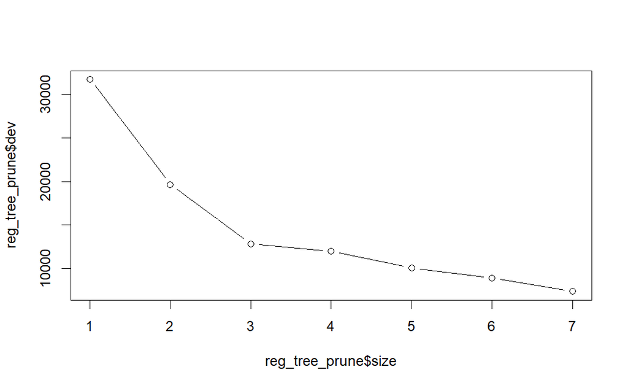

```r
reg_tree_prune <- cv.tree(reg_tree, K = 7 ) # k is the number of fold in the cv
plot(reg_tree_prune$size, reg_tree_prune$dev, type = "b")
```

The plot above basically indicates that the tree works best with 7 nodes, this makes sense but also defeats the purpose of trying to prune it SO we are going to use 5 to show what is happening.

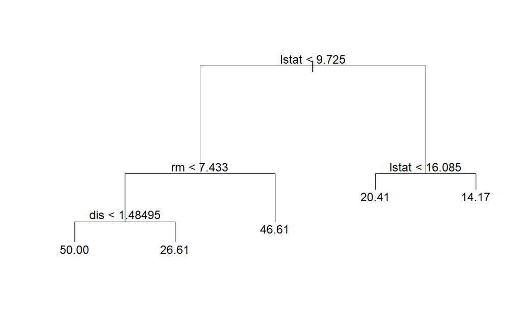

```r
reg_tree_pruned<-prune.tree(reg_tree, best = 5)
plot(reg_tree_pruned)
text(reg_tree_pruned, pretty=0)
```

When we trim the tree down to 5 nodes, we see that nox is dropped and we are just basing our decisions on lstat, rooms and distance from center.

We use the unpruned tree to make predictions on the test dataset

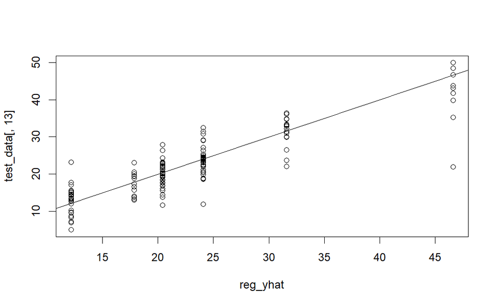

```r
reg_yhat<-predict(reg_tree, test_data)
plot(reg_yhat, test_data[, 13])
abline(0, 1)
```

Compute the test MSE

```r
mean((reg_yhat - test_data[, 13])^2)
```

```
[1] 18.05392
```

NOTE: The test set MSE associated with the regression tree is 18.05392 here. The square root of the MSE is therefore around 4.24, indicating that this model leads to test predictions that are (on average) within approximately $4,240 of the true median home value for the census tract. (This was better than your textbooks results 💵)

Remember we alrady partitioned the data earlier, but you would normal do that.

Set up Cross-validation:

```r
reg_control <-trainControl(method = "cv", number = 5) #using k = 5 folds
```

Model a regression tree

```r
reg_tree_1 <-train(medv~ . , data = train_data, method="rpart", trControl = reg_control)
```

```r
reg_tree_1
```

```
CART

356 samples
 12 predictor

No pre-processing
Resampling: Cross-Validated (5 fold)
Summary of sample sizes: 285, 286, 283, 285, 285
Resampling results across tuning parameters:

  cp          RMSE      Rsquared   MAE
  0.06524457  5.876715  0.6161103  4.251677
  0.19851992  7.435314  0.3940240  5.587039
  0.44547569  8.127808  0.3316416  5.997232

RMSE was used to select the optimal model using the smallest value.
The final value used for the model was cp = 0.06524457.
```

Plot the pruned tree

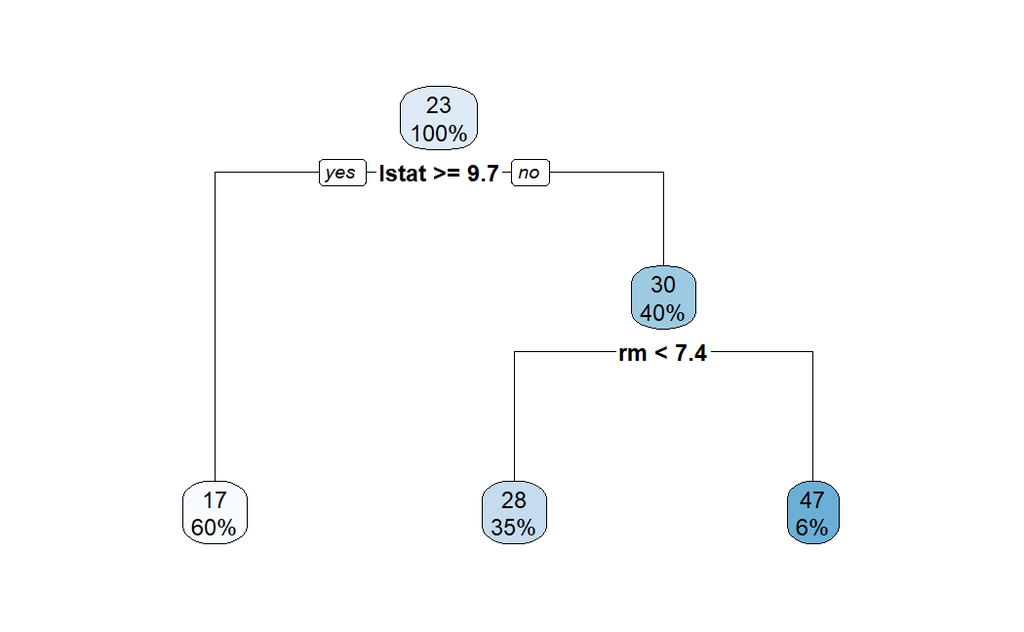

Find the MSE on the test data

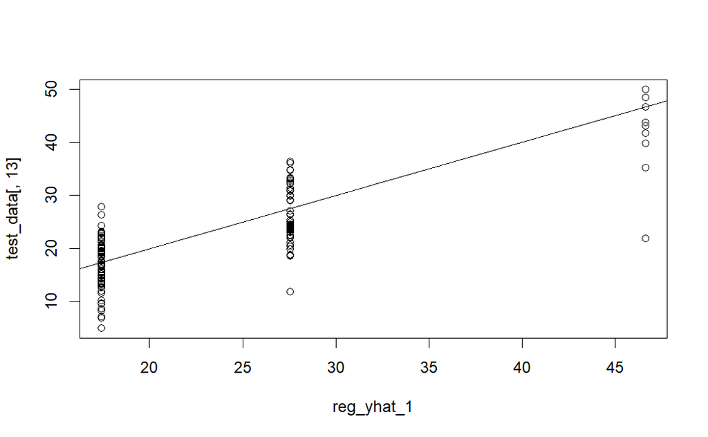

```r
reg_yhat_1 <- predict(reg_tree_1, test_data)
plot(reg_yhat_1, test_data[, 13])
abline(0,1)
```

```r
mean((reg_yhat_1 - test_data[, 13])^2)
```

```
[1] 29.6381
```